# BISC 481 Third Assignment for 1st Section of the Course (Rohs)

## Modeling of protein-DNA binding specificity/Statistical machine learning

### (1) Application of an open-source and distributed revision control project:

#### (a) Create a public repository with a README at GitHub https://github.com.

#### (b) Write your name in the file of README.md.

#### (c) Add a collaborator (username: TsuPeiChiu) to the repository. You are required to push your report and R scripts to the repository. The example and file template are shown in https://github.com/TsuPeiChiu/BISC481. 5 pts.

- https://github.com/chizksh/BISC481
- I wrote my name in README.md and also added TsuPeiChiu as a collaborator to my repo.

### (2) High-throughput binding assays: Briefly describe

#### (a) the in vitro experiments SELEX-seq and PBM, and

#### (b) the in vivo experiment ChlP-seq.

#### (c) Compare and discuss the advantage and disadvantage of these methods. 10 pts.

### (3) Preparation of high-throughput in vitro data analysis:

#### (a) Download and install R (version >= 3.3.0) from https://www.r-project.org.

#### (b) Install Bioconductor on your R platform. The installation instruction can be found at https://www.bioconductor.org/install/.

#### (c) Install package DNAshaper on your R platform. The installation instruction can be found at https://www.bioconductor.org/packages/devel/bioc/html/DNAshaper.html

#### (d) Install the machine learning package caret on your R platform. The installation instruction can be found at https://github.com/topepo/caret

```python
%reload_ext rpy2.ipython

# suppress excessive warnings such as RRuntimeWarning
import warnings
from rpy2.rinterface import RRuntimeWarning
warnings.filterwarnings("ignore", category=RRuntimeWarning)
import pandas as pd
```

```python
%%R
library("DNAshapeR")
library("caret")
library("ggpubr")
```

#### (e) Download the gcPBM in vitro experimental data of Mad, Max and Myc from https://github.com/TsuPeiChiu/BISC481/tree/master/gcPBM. 10 pts.

```python
!ls gcPBM/*.{txt,fa}
```

```
gcPBM/Mad.txt	  gcPBM/Max.txt     gcPBM/Myc.txt
gcPBM/Mad.txt.fa  gcPBM/Max.txt.fa  gcPBM/Myc.txt.fa
```

### (4) Build prediction models for in vitro data:

#### (a) Use the DNAshapeR package to generate a feature vector for “1-mer” sequence model and a feature vector for “1-mer+shape” model with respect to the datasets of Mad, Max and Myc.

```python
!head -n2 gcPBM/*.fa
```

```
==> gcPBM/Mad.txt.fa <==
>seq1
GGGCATGAAAGCCACCTCGTGGTTTTGCAGCAAGTG

==> gcPBM/Max.txt.fa <==
>seq1
GAAGCCCTGGCGGGGCGCGTGCCCGCCGCCGCCGCC

==> gcPBM/Myc.txt.fa <==
>seq1
ACCGACCGGCGCGGGCACGAGGCAATGGCGGCCGGG
```

```python
%%R
## current path
path <- getwd()

## fasta files
mad_seq <- paste0(path,"/gcPBM/Mad.txt.fa")
max_seq <- paste0(path,"/gcPBM/Max.txt.fa")
myc_seq <- paste0(path,"/gcPBM/Myc.txt.fa")

## print absolute path
print(mad_seq)
```

```
[1] "/auto/rcf-proj3/klj/kim130/BISC481/gcPBM/Mad.txt.fa"
```

```python
%%R
## helper function for feature vector
get_feature_vector = function(fn, featureType=c("1-mer", "1-shape")){
  pred <- getShape(fn)
  featureVector <- encodeSeqShape(fn, pred, featureType)
  return(featureVector)
}

## 1mer+shape
mad_fv_1mer_shape <- get_feature_vector(mad_seq,featureType=c("1-mer", "1-shape"))
max_fv_1mer_shape <- get_feature_vector(max_seq,featureType=c("1-mer", "1-shape"))
myc_fv_1mer_shape <- get_feature_vector(myc_seq,featureType=c("1-mer", "1-shape"))

## 1mer only
mad_fv_1mer <- get_feature_vector(mad_seq, featureType=c("1-mer"))
max_fv_1mer <- get_feature_vector(max_seq, featureType=c("1-mer"))
myc_fv_1mer <- get_feature_vector(myc_seq, featureType=c("1-mer"))
```

[output not shown]

#### (b) Use the caret package to build L2-regularized MLR models for “1-mer” and “1-mer+shape” features with 10-fold cross validation, and print out the average R2 (coefficient of determination) for these two models with respect to the Mad, Max and Myc datasets. 20 pts.

```python
!head -n1 gcPBM/*.txt
```

```
==> gcPBM/Mad.txt <==
GGGCATGAAAGCCACCTCGTGGTTTTGCAGCAAGTG	8.76342807395385

==> gcPBM/Max.txt <==
GAAGCCCTGGCGGGGCGCGTGCCCGCCGCCGCCGCC	3.737828506

==> gcPBM/Myc.txt <==
ACCGACCGGCGCGGGCACGAGGCAATGGCGGCCGGG	7.84737183615979
```

```python
%%R
## helper function for build MLR model
build_MLR_model <- function(affinity_table, fv, fold){
  exp_data <- read.table(affinity_table)
  df <- data.frame(affinity=exp_data$V2, fv)
  train_ctrl <- trainControl(method ="cv", number=fold, savePredictions = TRUE)
  model <- train(affinity~ ., data=df, trControl=train_ctrl,
                 method="lm", preProcess=NULL)
  return(model)
}

## Binding Affinity files
mad_ba = paste0(path,"/gcPBM/Mad.txt")
max_ba = paste0(path,"/gcPBM/Max.txt")
myc_ba = paste0(path,"/gcPBM/Myc.txt")
```

```python
%%R
## 1mer+shape
mad_model_1mer_shape <- build_MLR_model(mad_ba, mad_fv_1mer_shape, 10)
max_model_1mer_shape <- build_MLR_model(max_ba, max_fv_1mer_shape, 10)
myc_model_1mer_shape <- build_MLR_model(myc_ba, myc_fv_1mer_shape, 10)

## 1mer only
mad_model_1mer <- build_MLR_model(mad_ba, mad_fv_1mer, 10)
max_model_1mer <- build_MLR_model(max_ba, max_fv_1mer, 10)
myc_model_1mer <- build_MLR_model(myc_ba, myc_fv_1mer, 10)
```

```python
%%R
## helper function for getting rsquared value
get_rsquared <- function(model){
  return(model$results$Rsquared)
}

## getting rsquared
print(c(get_rsquared(mad_model_1mer_shape),get_rsquared(max_model_1mer_shape),get_rsquared(myc_model_1mer_shape)))
print(c(get_rsquared(mad_model_1mer),get_rsquared(max_model_1mer),get_rsquared(myc_model_1mer)))
```

```
[1] 0.9568596 0.9343812 0.9212755
[1] 0.7761577 0.7855131 0.7787994
```

### (5) High-throughput in vitro data analysis:

#### (a) Draw a plot for the comparison of two different models (1mer vs. 1mer+shape) as shown in Figure 1B of Zhou et al. PNAS 2015.

[figure not shown]

```python
%%R -w 540 -h 480 -u px
## making dataframe for plotting
comp_model <- data.frame(
  TFs = c("Mad","Max","Myc"),
  rsqr_1mer = c(get_rsquared(mad_model_1mer),get_rsquared(max_model_1mer),get_rsquared(myc_model_1mer)),
  rsqr_1mer_shape = c(get_rsquared(mad_model_1mer_shape),get_rsquared(max_model_1mer_shape),get_rsquared(myc_model_1mer_shape))
)

## plotting
ggscatter(comp_model, x="rsqr_1mer", y="rsqr_1mer_shape", ylim=c(0,1.0), xlim=c(0,1.0), color="TFs", shape="TFs", theme=theme_pubclean(), legend="right") + geom_abline(intercept=0, slope=1, linetype="dashed") + xlab(expression(atop("1mer "*R^{2}, "(sequence+shape model)"))) + ylab(expression(atop("1mer+shape "*R^{2},"(sequence model)")))
```

#### (b) Briefly discuss what you have learned from the results. 15 pts.

### (6) Preparation of high-throughput in vivo data analysis:

#### (a) Download the ChIP-seq data (including “bound” and “non-bound" data) of CTCF transcription factor of Mus musculus from https://github.com/TsuPeiChiu/BISC481/tree/master/CTCF.

#### (b) Install the R packages mentioned in question (3). 5 pts.

```python
!ls CTCF/*.fa
```

```
CTCF/bound_30.fa   CTCF/bound.fa  CTCF/unbound_30.fa   CTCF/unbound.fa
CTCF/bound_500.fa  CTCF/ctcf.fa   CTCF/unbound_500.fa
```

### (7) High-throughput in vivo data analysis:

#### (a) Use plotShape() or heatShape() functions of DNAshapeR to generate ensemble plots for the DNA shape parameters of minor groove width (MGW), propeller twist (ProT), Roll, and helix twist (HelT) based on the sequences downloaded for question (6).

```python
%%R
## file path
bound_30_seq <- paste0(path,"/CTCF/bound_30.fa")
unbound_30_seq <- paste0(path,"/CTCF/unbound_30.fa")
bound_seq <- paste0(path,"/CTCF/bound.fa")
unbound_seq <- paste0(path,"/CTCF/unbound.fa")
bound_500_seq <- paste0(path,"/CTCF/bound_500.fa")
unbound_500_seq <- paste0(path,"/CTCF/unbound_500.fa")

## print absolute path
print(bound_30_seq)
```

```
[1] "/auto/rcf-proj3/klj/kim130/BISC481/CTCF/bound_30.fa"
```

```python
%%R

## helper function for emsembl plotting
get_ensembl_plots <- function(fn){
    pred <- getShape(fn)
    par(mfrow=c(2,4))
    plotShape(pred$MGW)
    plotShape(pred$ProT)
    plotShape(pred$Roll)
    plotShape(pred$HelT)
    heatShape(pred$MGW,dim(pred$MGW)[2])
    heatShape(pred$ProT,dim(pred$ProT)[2])
    heatShape(pred$Roll,dim(pred$Roll)[2])
    heatShape(pred$HelT,dim(pred$HelT)[2])
}
```

```
Reading the input sequence......
Reading the input sequence......
Reading the input sequence......
Reading the input sequence......
Reading the input sequence......
```

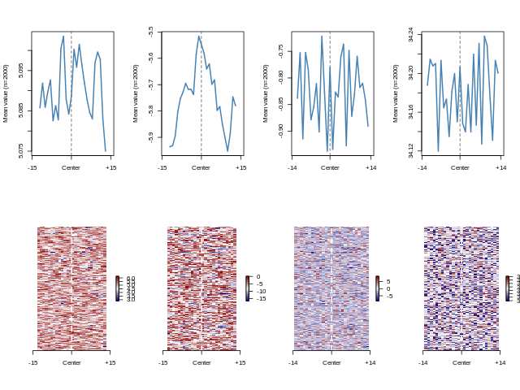

```python
%%R -w 640 -h 480 -u px
get_ensembl_plots(bound_30_seq)
```

```
Reading the input sequence......
Reading the input sequence......
Reading the input sequence......
Reading the input sequence......
Reading the input sequence......
```

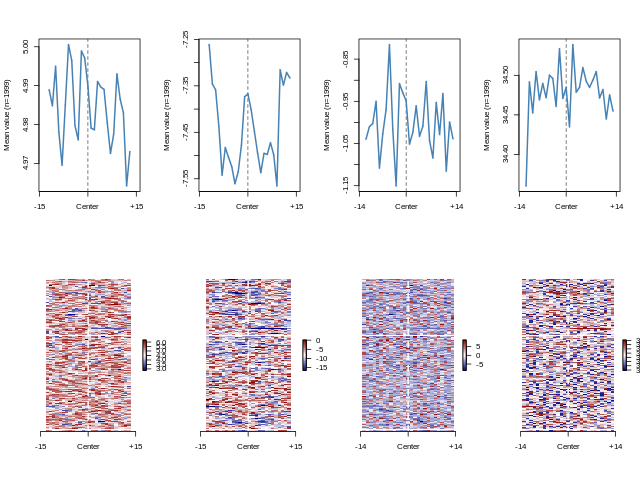

```python
%%R -w 640 -h 480 -u px
get_ensembl_plots(unbound_30_seq)
```

```
Reading the input sequence......
Reading the input sequence......
Reading the input sequence......
Reading the input sequence......
Reading the input sequence......
```

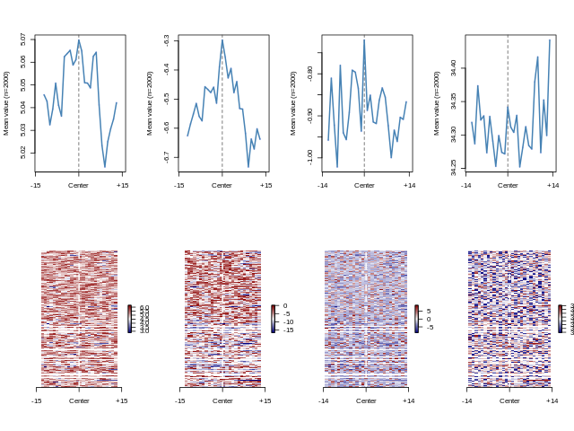

```python
%%R -w 640 -h 480 -u px
get_ensembl_plots(bound_seq)
```

```
Reading the input sequence......
Reading the input sequence......
Reading the input sequence......
Reading the input sequence......
Reading the input sequence......
```

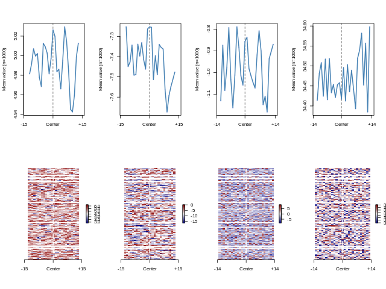

```python
%%R -w 640 -h 480 -u px
get_ensembl_plots(unbound_seq)
```

```
Reading the input sequence......
Reading the input sequence......
Reading the input sequence......
Reading the input sequence......
Reading the input sequence......
```

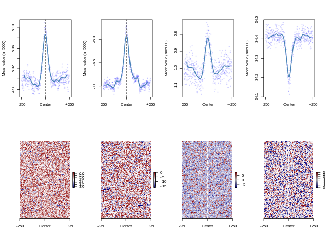

```python
%%R -w 640 -h 480 -u px
get_ensembl_plots(bound_500_seq)
```

```
Reading the input sequence......
Reading the input sequence......
Reading the input sequence......
Reading the input sequence......
Reading the input sequence......
```

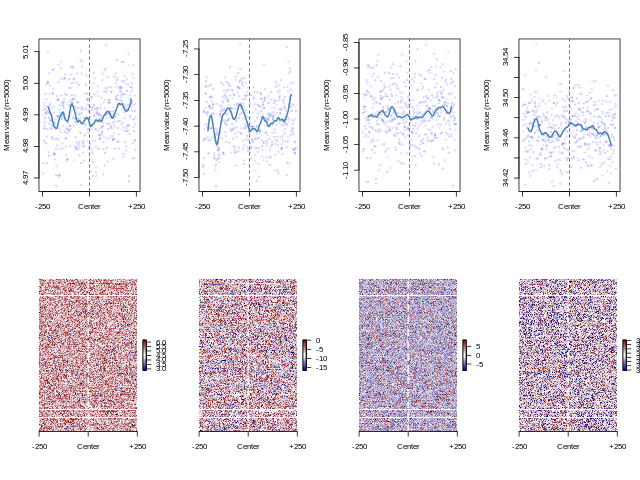

```python
%%R -w 640 -h 480 -u px
get_ensembl_plots(unbound_500_seq)
```

#### (b) Briefly discuss what you have learned from the results. 15 pts.

### (8) Build prediction models for in vitro data:

#### (a) Build logistic regression models for "1-mer" and "1 mer+shape” features, draw a plot of the ROC curves, and calculate the AUC score for each curve.

```python
%%R
## import library
library("DNAshapeR")
library("caret")
library("ROCR")
library("Biostrings")
# For Multicore
library(doMC)
registerDoMC(cores=16) # 10 cores are enough for 10-CV
```

```python
%%R
## current path
path <- getwd()

## file path
bound_30_seq <- paste0(path,"/CTCF/bound_30.fa")
unbound_30_seq <- paste0(path,"/CTCF/unbound_30.fa")
bound_seq <- paste0(path,"/CTCF/bound.fa")
unbound_seq <- paste0(path,"/CTCF/unbound.fa")
bound_500_seq <- paste0(path,"/CTCF/bound_500.fa")
unbound_500_seq <- paste0(path,"/CTCF/unbound_500.fa")

## print absolute path
print(bound_30_seq)
```

```
[1] "/auto/rcf-proj3/klj/kim130/BISC481/CTCF/bound_30.fa"
```

##### Build regression models based on bound_500 / unbound_500

```python
%%R
## Generate data for the classifcation (assign Y to bound and N to non-bound)
# bound_500
bound_500_fasta <- readDNAStringSet(bound_500_seq)
bound_txt <- data.frame(seq=paste(bound_500_fasta), isBound="Y")

# unbound_500
unbound_500_fasta <- readDNAStringSet(unbound_500_seq)
unbound_txt <- data.frame(seq=paste(unbound_500_fasta), isBound="N")

# merge two datasets
writeXStringSet( c(bound_500_fasta, unbound_500_fasta), paste0(path, "/CTCF/ctcf.fa"))
exp_data <- rbind(bound_txt, unbound_txt)

## check exp_data
c(head(exp_data,n=1), tail(exp_data,n=1))
```

```
$seq
[1] AAAATAAAATAAATAAAAAACAAGCAAAACCATGTGGTATTGTGAGTCTTTTCTTAAGCT…
9444 Levels: AAAAAAAAAAAAAAAAAAAAAAAAGGTAGAAGAAGAAAAAGGGCGGGGGGGGGATATGAG… ...

$isBound
[1] Y
Levels: Y N

$seq
[1] AACAGAGGCGGGCTTGTTCGACTAATGATTGCATTTTCCCTATTTTGTTAACTATAAGAA…
9444 Levels: AAAAAAAAAAAAAAAAAAAAAAAAGGTAGAAGAAGAAAAAGGGCGGGGGGGGGATATGAG… ...

$isBound
[1] N
Levels: Y N
```

```python
!grep -c "^>" CTCF/*.fa
```

```
CTCF/bound_30.fa:2000
CTCF/bound_500.fa:5000
CTCF/bound.fa:2000
CTCF/ctcf.fa:10000
CTCF/unbound_30.fa:1999
CTCF/unbound_500.fa:5000
CTCF/unbound.fa:1000
```

```python
%%R
## DNAshapeR prediction
pred <- getShape(paste0(path, "/CTCF/ctcf.fa"))
```

```
Reading the input sequence......
Reading the input sequence......
Reading the input sequence......
Reading the input sequence......
Reading the input sequence......
```

```python
%%R
## Encode feature vectors
featureType <- c("1-mer", "1-shape")
featureVector <- encodeSeqShape(paste0(path, "/CTCF/ctcf.fa"), pred, featureType)
df <- data.frame(isBound = exp_data$isBound, featureVector)
head(df,n=1)
```

[output not shown]

Due to the memory performance issue, save and load the dataframe: for 10-CV, 40G memory and 10 CPU cores can be used.

```python
%%R
saveRDS(df, file="ctcf_encoded.rds")
```

```python
%%R
df2 <- readRDS("ctcf_encoded.rds")
```

```python
%%R
## Logistic regression

# Set parameters for Caret
trainControl <- trainControl(method = "cv", number = 10,
                             savePredictions = TRUE, classProbs = TRUE)
# Perform prediction
model <- train(isBound~ ., data = df2, trControl = trainControl,
               method = "glm", family = binomial, metric ="ROC")
```

```python
%%R
summary(model)
```

[output not shown]

```
[1] "auc: 0.68911192"
```

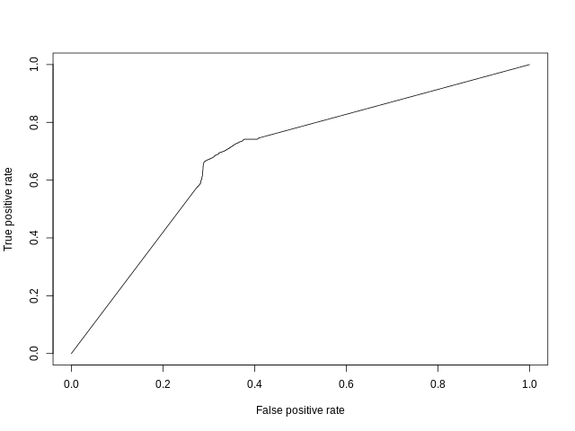

```python
%%R -w 640 -h 480 -u px
## Plot AUROC
prediction <- prediction( model$pred$Y, model$pred$obs )
performance <- performance( prediction, "tpr", "fpr" )
plot(performance)

## Caluculate AUROC
auc <- performance(prediction, "auc")
auc <- unlist(slot(auc, "y.values"))
print(paste("auc:",auc))
```

##### Same procedures with pre-computed models with bound/unbound_30, bound/unbound

```python
%%R
## helper function for plotting and calculating AUROC
plot_cal_AUROC <- function(model){
    ## Plot AUROC
    prediction <- prediction( model$pred$Y, model$pred$obs )
    performance <- performance( prediction, "tpr", "fpr" )
    plot(performance)

    ## Caluculate AUROC
    auc <- performance(prediction, "auc")
    auc <- unlist(slot(auc, "y.values"))
    print(paste("auc:",auc))

}
```

```
[1] "auc: 0.838595047523762"
```

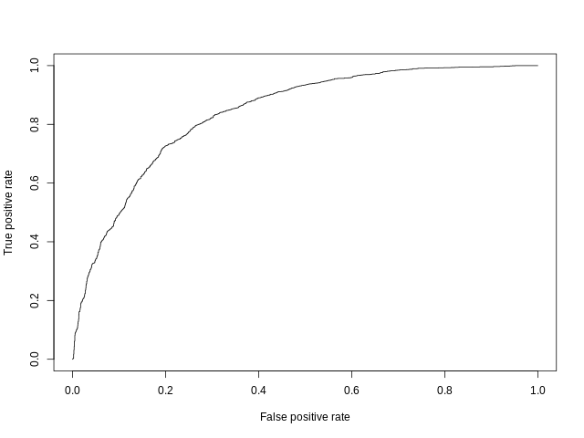

```python
%%R -w 640 -h 480 -u px
##Pre-computed model with bound_30, unbound_30
model_30 <- readRDS("model_30.rds")
plot_cal_AUROC(model_30)
```

```
[1] "auc: 0.577608500000001"
```

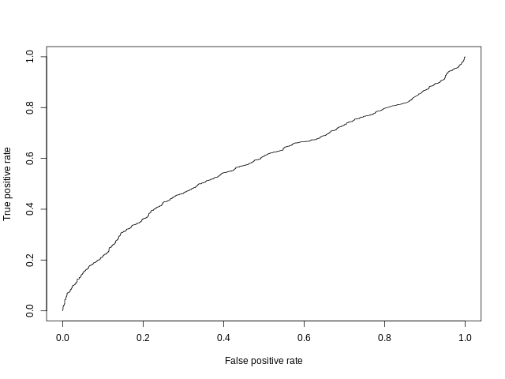

```python
%%R -w 640 -h 480 -u px
##Pre-computed model with bound, unbound
model <- readRDS("model.rds")
plot_cal_AUROC(model)
```